# Ciprofloxacin resistance in Klebsiella pneumoniae

Iana Amke, Kara Tsang, Kat Holt

Last compiled on 20/09/24

# load data

```r
geno <- read_delim("tables/TableS1_genotypes.tsv")

pheno <- read_delim("tables/TableS2_phenotypes_metadata.tsv")

cipro_antibiogram <- full_join(geno,pheno)
```

# upset plots

## test effect of QRDR, in absence of any acquired genes

```r
mic <- cipro_antibiogram %>%
  filter(grepl('MIC.*$', Laboratory.Typing.Method))

# MIC
QRDR_MIC_noGenes_dat <- mic %>%
    filter(aac6==0 & acquired_genes==0) %>%
  select(Measurement, Resistance.phenotype, resistant, nonWT_binary, QRDR_mutations, GyrA83, ParC80) %>%
  mutate(qrdr_bin=if_else(QRDR_mutations==0, 0, 1))

# MIC vs presence/absence
wilcox.test(log2(as.numeric(Measurement)) ~ qrdr_bin, data=QRDR_MIC_noGenes_dat)
```

```
##
##  Wilcoxon rank sum test with continuity correction
##
## data:  log2(as.numeric(Measurement)) by qrdr_bin
## W = 111846, p-value < 2.2e-16
## alternative hypothesis: true location shift is not equal to 0
```

```r
t.test(log2(as.numeric(Measurement)) ~ qrdr_bin, data=QRDR_MIC_noGenes_dat)
```

```
##
##  Welch Two Sample t-test
##
## data:  log2(as.numeric(Measurement)) by qrdr_bin
## t = -102.37, df = 2760.6, p-value < 2.2e-16
## alternative hypothesis: true difference in means between group 0 and group 1 is not equal to 0
## 95 percent confidence interval:
##  -3.174671 -3.055344
## sample estimates:
## mean in group 0 mean in group 1
##       -1.944217        1.170791
```

```r
summary(lm(log2(as.numeric(Measurement)) ~ qrdr_bin, data=QRDR_MIC_noGenes_dat))
```

```
##
## Call:
## lm(formula = log2(as.numeric(Measurement)) ~ qrdr_bin, data = QRDR_MIC_noGenes_dat)
##
## Residuals:
##     Min      1Q  Median      3Q     Max
## -4.1708 -0.1708 -0.0558 -0.0558  7.9442
##
## Coefficients:
##             Estimate Std. Error t value Pr(>|t|)
## (Intercept) -1.94422    0.01661  -117.1   <2e-16 ***
## qrdr_bin     3.11501    0.02830   110.1   <2e-16 ***
## ---
## Signif. codes:  0 '***' 0.001 '**' 0.01 '*' 0.05 '.' 0.1 ' ' 1
##
## Residual standard error: 0.9326 on 4809 degrees of freedom
## Multiple R-squared:  0.7159, Adjusted R-squared:  0.7158
## F-statistic: 1.212e+04 on 1 and 4809 DF,  p-value: < 2.2e-16
```

```r
summary(as.numeric(QRDR_MIC_noGenes_dat$Measurement)[QRDR_MIC_noGenes_dat$qrdr_bin==1])
```

```
##    Min. 1st Qu.  Median    Mean 3rd Qu.    Max.
##   0.125   2.000   2.000   5.525   2.000 512.000
```

```r
summary(as.numeric(QRDR_MIC_noGenes_dat$Measurement)[QRDR_MIC_noGenes_dat$qrdr_bin==0])
```

```
##    Min. 1st Qu.  Median    Mean 3rd Qu.    Max.
##  0.0300  0.2500  0.2500  0.3464  0.2500 64.0000
```

```r
# MIC vs QRDR count
QRDR_MIC_noGenes_dat <- QRDR_MIC_noGenes_dat %>%
  mutate(QRDR_0_1_2 = if_else(QRDR_mutations>2, 2, QRDR_mutations)) %>%
  mutate(QRDR_0_1_2_3 = if_else(QRDR_mutations>3, 3, QRDR_mutations)) %>%
  mutate(QRDR_1_2 = if_else(QRDR_0_1_2==0, NA, QRDR_0_1_2)) %>%
  mutate(QRDR_2_3 = if_else(QRDR_0_1_2<2, NA, QRDR_0_1_2_3))

summary(lm(log2(as.numeric(Measurement)) ~ QRDR_mutations, data=QRDR_MIC_noGenes_dat))
```

```
##
## Call:
## lm(formula = log2(as.numeric(Measurement)) ~ QRDR_mutations,
##     data = QRDR_MIC_noGenes_dat)
##
## Residuals:
##     Min      1Q  Median      3Q     Max
## -4.5645 -0.1174 -0.1174 -0.1174  8.5845
##
## Coefficients:
##                Estimate Std. Error t value Pr(>|t|)
## (Intercept)    -1.88258    0.01725  -109.1   <2e-16 ***
## QRDR_mutations  1.14904    0.01122   102.4   <2e-16 ***
## ---
## Signif. codes:  0 '***' 0.001 '**' 0.01 '*' 0.05 '.' 0.1 ' ' 1
##
## Residual standard error: 0.9811 on 4809 degrees of freedom
## Multiple R-squared:  0.6856, Adjusted R-squared:  0.6855
## F-statistic: 1.049e+04 on 1 and 4809 DF,  p-value: < 2.2e-16
```

```r
summary(lm(log2(as.numeric(Measurement)) ~ factor(QRDR_mutations), data=QRDR_MIC_noGenes_dat))
```

```
##
## Call:
## lm(formula = log2(as.numeric(Measurement)) ~ factor(QRDR_mutations),
##     data = QRDR_MIC_noGenes_dat)
##
## Residuals:
##     Min      1Q  Median      3Q     Max
## -4.2661 -0.0860 -0.0558 -0.0558  7.9442
##
## Coefficients:
##                         Estimate Std. Error t value Pr(>|t|)
## (Intercept)             -1.94422    0.01653 -117.62   <2e-16 ***
## factor(QRDR_mutations)1  2.49977    0.11064   22.59   <2e-16 ***
## factor(QRDR_mutations)2  3.03022    0.04155   72.93   <2e-16 ***
## factor(QRDR_mutations)3  3.21035    0.03379   95.00   <2e-16 ***
## ---
## Signif. codes:  0 '***' 0.001 '**' 0.01 '*' 0.05 '.' 0.1 ' ' 1
##
## Residual standard error: 0.9283 on 4807 degrees of freedom
## Multiple R-squared:  0.7187, Adjusted R-squared:  0.7185
## F-statistic:  4093 on 3 and 4807 DF,  p-value: < 2.2e-16
```

```r
summary(lm(log2(as.numeric(Measurement)) ~ factor(QRDR_0_1_2), data=QRDR_MIC_noGenes_dat))
```

```
##
## Call:
## lm(formula = log2(as.numeric(Measurement)) ~ factor(QRDR_0_1_2),
##     data = QRDR_MIC_noGenes_dat)
##
## Residuals:
##     Min      1Q  Median      3Q     Max
## -4.1987 -0.1987 -0.0558 -0.0558  7.9442
##
## Coefficients:
##                     Estimate Std. Error t value Pr(>|t|)
## (Intercept)         -1.94422    0.01655 -117.47   <2e-16 ***
## factor(QRDR_0_1_2)1  2.49977    0.11079   22.56   <2e-16 ***
## factor(QRDR_0_1_2)2  3.14296    0.02862  109.82   <2e-16 ***
## ---
## Signif. codes:  0 '***' 0.001 '**' 0.01 '*' 0.05 '.' 0.1 ' ' 1
##
## Residual standard error: 0.9295 on 4808 degrees of freedom
## Multiple R-squared:  0.7178, Adjusted R-squared:  0.7177
## F-statistic:  6116 on 2 and 4808 DF,  p-value: < 2.2e-16
```

```r
summary(lm(log2(as.numeric(Measurement)) ~ factor(QRDR_1_2), data=QRDR_MIC_noGenes_dat))
```

```
##
## Call:
## lm(formula = log2(as.numeric(Measurement)) ~ factor(QRDR_1_2),
##     data = QRDR_MIC_noGenes_dat)
##
## Residuals:
##     Min      1Q  Median      3Q     Max
## -4.1987 -0.1987 -0.1987 -0.1987  7.8013
##
## Coefficients:
##                   Estimate Std. Error t value Pr(>|t|)
## (Intercept)         0.5556     0.1258   4.416 1.07e-05 ***
## factor(QRDR_1_2)2   0.6432     0.1286   5.000 6.34e-07 ***
## ---
## Signif. codes:  0 '***' 0.001 '**' 0.01 '*' 0.05 '.' 0.1 ' ' 1
##
## Residual standard error: 1.068 on 1655 degrees of freedom
##   (3154 observations deleted due to missingness)
## Multiple R-squared:  0.01488,    Adjusted R-squared:  0.01429
## F-statistic:    25 on 1 and 1655 DF,  p-value: 6.344e-07
```

```r
summary(lm(log2(as.numeric(Measurement)) ~ factor(QRDR_2_3), data=QRDR_MIC_noGenes_dat))
```

```
##
## Call:
## lm(formula = log2(as.numeric(Measurement)) ~ factor(QRDR_2_3),
##     data = QRDR_MIC_noGenes_dat)
##
## Residuals:
##     Min      1Q  Median      3Q     Max
## -4.2661 -0.2661 -0.2661 -0.0860  7.9140
##
## Coefficients:
##                   Estimate Std. Error t value Pr(>|t|)
## (Intercept)        1.08600    0.04281  25.368  < 2e-16 ***
## factor(QRDR_2_3)3  0.18013    0.05411   3.329 0.000893 ***
## ---
## Signif. codes:  0 '***' 0.001 '**' 0.01 '*' 0.05 '.' 0.1 ' ' 1
##
## Residual standard error: 1.042 on 1583 degrees of freedom
##   (3226 observations deleted due to missingness)
## Multiple R-squared:  0.006951,   Adjusted R-squared:  0.006324
## F-statistic: 11.08 on 1 and 1583 DF,  p-value: 0.0008925
```

```r
summary(as.numeric(QRDR_MIC_noGenes_dat$Measurement)[QRDR_MIC_noGenes_dat$QRDR_mutations==1])
```

```
##    Min. 1st Qu.  Median    Mean 3rd Qu.    Max.
##   0.125   1.000   1.000   2.592   2.000  16.000
```

```r
summary(as.numeric(QRDR_MIC_noGenes_dat$Measurement)[QRDR_MIC_noGenes_dat$QRDR_mutations==2])
```

```
##    Min. 1st Qu.  Median    Mean 3rd Qu.    Max.
##   0.250   2.000   2.000   4.674   2.000 512.000
```

```r
summary(as.numeric(QRDR_MIC_noGenes_dat$Measurement)[QRDR_MIC_noGenes_dat$QRDR_mutations>2])
```

```
##    Min. 1st Qu.  Median    Mean 3rd Qu.    Max.
##   0.125   2.000   2.000   6.247   2.000 512.000
```

```r
# effect of ParC when added to GyrA83 background (absence of any genes or GyrA87)
QRDR_MIC_GyrA83background_noGenes_dat <- mic %>%
    filter(aac6==0 & acquired_genes==0 & GyrA83==1 & GyrA87==0) %>%
  select(Measurement, Resistance.phenotype, resistant, nonWT_binary, ParC_mutations, ParC80, ParC84)

wilcox.test(log2(as.numeric(Measurement)) ~ ParC80, data=QRDR_MIC_GyrA83background_noGenes_dat)
```

```
##
##  Wilcoxon rank sum test with continuity correction
##
## data:  log2(as.numeric(Measurement)) by ParC80
## W = 13836, p-value = 0.001951
## alternative hypothesis: true location shift is not equal to 0
```

```r
t.test(log2(as.numeric(Measurement)) ~ ParC80, data=QRDR_MIC_GyrA83background_noGenes_dat)
```

```
##
##  Welch Two Sample t-test
##
## data:  log2(as.numeric(Measurement)) by ParC80
## t = -1.2697, df = 63.334, p-value = 0.2089
## alternative hypothesis: true difference in means between group 0 and group 1 is not equal to 0
## 95 percent confidence interval:
##  -0.7150788  0.1594104
## sample estimates:
## mean in group 0 mean in group 1
##        0.800000        1.077834
```

```r
summary(lm(log2(as.numeric(Measurement)) ~ ParC80, data=QRDR_MIC_GyrA83background_noGenes_dat))
```

```
##
## Call:
## lm(formula = log2(as.numeric(Measurement)) ~ ParC80, data = QRDR_MIC_GyrA83background_noGenes_dat)
##
## Residuals:
##     Min      1Q  Median      3Q     Max
## -3.8000 -0.0778 -0.0778  0.0611  7.9222
##
## Coefficients:
##             Estimate Std. Error t value Pr(>|t|)
## (Intercept)   0.8000     0.1384   5.780 1.16e-08 ***
## ParC80        0.2778     0.1453   1.913   0.0562 .
## ---
## Signif. codes:  0 '***' 0.001 '**' 0.01 '*' 0.05 '.' 0.1 ' ' 1
##
## Residual standard error: 1.072 on 649 degrees of freedom
## Multiple R-squared:  0.005605,   Adjusted R-squared:  0.004072
## F-statistic: 3.658 on 1 and 649 DF,  p-value: 0.05625
```

```r
summary(as.numeric(QRDR_MIC_GyrA83background_noGenes_dat$Measurement)[QRDR_MIC_GyrA83background_noGenes_dat$ParC80==1])
```

```
##    Min. 1st Qu.  Median    Mean 3rd Qu.    Max.
##   0.250   2.000   2.000   4.471   2.000 512.000
```

```r
summary(as.numeric(QRDR_MIC_GyrA83background_noGenes_dat$Measurement)[QRDR_MIC_GyrA83background_noGenes_dat$ParC80==0])
```

```
##    Min. 1st Qu.  Median    Mean 3rd Qu.    Max.
##   0.125   1.000   1.000   4.948   4.000 128.000
```

```r
# DD
QRDR_DD_noGenes_dat <- cipro_antibiogram %>%
    filter(aac6==0 & acquired_genes==0) %>%
    filter(Laboratory.Typing.Method=="Disk diffusion") %>%
  select(Measurement, Resistance.phenotype, resistant, nonWT_binary, QRDR_mutations) %>%
  mutate(qrdr_bin=if_else(QRDR_mutations==0, 0, 1))

QRDR_DD_noGenes_dat <- QRDR_DD_noGenes_dat %>%
  mutate(QRDR_0_1_2 = if_else(QRDR_mutations>2, 2, QRDR_mutations)) %>%
  mutate(QRDR_0_1_2_3 = if_else(QRDR_mutations>3, 3, QRDR_mutations)) %>%
  mutate(QRDR_1_2 = if_else(QRDR_0_1_2==0, NA, QRDR_0_1_2)) %>%
  mutate(QRDR_2_3 = if_else(QRDR_0_1_2<2, NA, QRDR_0_1_2_3))

# DD vs presence/absence
wilcox.test(as.numeric(Measurement) ~ qrdr_bin, data=QRDR_DD_noGenes_dat)
```

```
##
##  Wilcoxon rank sum test with continuity correction
##
## data:  as.numeric(Measurement) by qrdr_bin
## W = 320646, p-value < 2.2e-16
## alternative hypothesis: true location shift is not equal to 0
```

```r
t.test(as.numeric(Measurement) ~ qrdr_bin, data=QRDR_DD_noGenes_dat)
```

```
##
##  Welch Two Sample t-test
##
## data:  as.numeric(Measurement) by qrdr_bin
## t = 28.219, df = 131.45, p-value < 2.2e-16
## alternative hypothesis: true difference in means between group 0 and group 1 is not equal to 0
## 95 percent confidence interval:
##  15.60486 17.95765
## sample estimates:
## mean in group 0 mean in group 1
##        28.66587        11.88462
```

```r
summary(lm(as.numeric(Measurement) ~ qrdr_bin, data=QRDR_DD_noGenes_dat))
```

```
##
## Call:
## lm(formula = as.numeric(Measurement) ~ qrdr_bin, data = QRDR_DD_noGenes_dat)
##
## Residuals:
##      Min       1Q   Median       3Q      Max
## -22.6659  -1.6659   0.3341   1.3341  18.1154
##
## Coefficients:
##              Estimate Std. Error t value Pr(>|t|)
## (Intercept)  28.66587    0.06349  451.51   <2e-16 ***
## qrdr_bin    -16.78125    0.28616  -58.64   <2e-16 ***
## ---
## Signif. codes:  0 '***' 0.001 '**' 0.01 '*' 0.05 '.' 0.1 ' ' 1
##
## Residual standard error: 3.181 on 2639 degrees of freedom
## Multiple R-squared:  0.5658, Adjusted R-squared:  0.5656
## F-statistic:  3439 on 1 and 2639 DF,  p-value: < 2.2e-16
```

```r
summary(as.numeric(QRDR_DD_noGenes_dat$Measurement)[QRDR_DD_noGenes_dat$qrdr_bin==1])
```

```
##    Min. 1st Qu.  Median    Mean 3rd Qu.    Max.
##    6.00    6.00    9.00   11.88   17.00   30.00
```

```r
summary(as.numeric(QRDR_DD_noGenes_dat$Measurement)[QRDR_DD_noGenes_dat$qrdr_bin==0])
```

```
##    Min. 1st Qu.  Median    Mean 3rd Qu.    Max.
##    6.00   27.00   29.00   28.67   30.00   44.00
```

```r
# DD vs QRDR count
summary(lm(as.numeric(Measurement) ~ QRDR_mutations, data=QRDR_DD_noGenes_dat))
```

```
##
## Call:
## lm(formula = as.numeric(Measurement) ~ QRDR_mutations, data = QRDR_DD_noGenes_dat)
##
## Residuals:
##      Min       1Q   Median       3Q      Max
## -22.6378  -1.6378   0.3622   1.3622  17.6985
##
## Coefficients:
##                Estimate Std. Error t value Pr(>|t|)
## (Intercept)     28.6378     0.0596  480.52   <2e-16 ***
## QRDR_mutations  -8.1682     0.1259  -64.89   <2e-16 ***
## ---
## Signif. codes:  0 '***' 0.001 '**' 0.01 '*' 0.05 '.' 0.1 ' ' 1
##
## Residual standard error: 2.997 on 2639 degrees of freedom
## Multiple R-squared:  0.6147, Adjusted R-squared:  0.6146
## F-statistic:  4211 on 1 and 2639 DF,  p-value: < 2.2e-16
```

```r
summary(as.numeric(QRDR_DD_noGenes_dat$Measurement)[QRDR_DD_noGenes_dat$QRDR_mutations==1])
```

```
##    Min. 1st Qu.  Median    Mean 3rd Qu.    Max.
##   11.00   17.00   20.50   19.75   22.25   29.00
```

```r
summary(as.numeric(QRDR_DD_noGenes_dat$Measurement)[QRDR_DD_noGenes_dat$QRDR_mutations==2])
```

```
##    Min. 1st Qu.  Median    Mean 3rd Qu.    Max.
##   6.000   6.000   6.000   9.585  13.000  30.000
```

```r
summary(as.numeric(QRDR_DD_noGenes_dat$Measurement)[QRDR_DD_noGenes_dat$QRDR_mutations>2])
```

```
##    Min. 1st Qu.  Median    Mean 3rd Qu.    Max.
##   6.000   6.000   6.000   6.676   6.000  12.000
```

```r
summary(lm(log2(as.numeric(Measurement)) ~ QRDR_mutations, data=QRDR_DD_noGenes_dat))
```

```
##
## Call:
## lm(formula = log2(as.numeric(Measurement)) ~ QRDR_mutations,
##     data = QRDR_DD_noGenes_dat)
##
## Residuals:
##      Min       1Q   Median       3Q      Max
## -2.24831 -0.07839  0.02471  0.07362  1.57431
##
## Coefficients:
##                 Estimate Std. Error t value Pr(>|t|)
## (Intercept)     4.833275   0.003884 1244.46   <2e-16 ***
## QRDR_mutations -0.750349   0.008203  -91.47   <2e-16 ***
## ---
## Signif. codes:  0 '***' 0.001 '**' 0.01 '*' 0.05 '.' 0.1 ' ' 1
##
## Residual standard error: 0.1953 on 2639 degrees of freedom
## Multiple R-squared:  0.7602, Adjusted R-squared:  0.7601
## F-statistic:  8367 on 1 and 2639 DF,  p-value: < 2.2e-16
```

```r
summary(lm(log2(as.numeric(Measurement)) ~ factor(QRDR_mutations), data=QRDR_DD_noGenes_dat))
```

```
##
## Call:
## lm(formula = log2(as.numeric(Measurement)) ~ factor(QRDR_mutations),
##     data = QRDR_DD_noGenes_dat)
##
## Residuals:
##      Min       1Q   Median       3Q      Max
## -2.24805 -0.07812  0.02497  0.07388  1.80245
##
## Coefficients:
##                          Estimate Std. Error t value Pr(>|t|)
## (Intercept)              4.833011   0.003796 1273.23   <2e-16 ***
## factor(QRDR_mutations)1 -0.564658   0.030313  -18.63   <2e-16 ***
## factor(QRDR_mutations)2 -1.728573   0.026402  -65.47   <2e-16 ***
## factor(QRDR_mutations)3 -2.123440   0.031928  -66.51   <2e-16 ***
## factor(QRDR_mutations)4 -2.248048   0.190248  -11.82   <2e-16 ***
## ---
## Signif. codes:  0 '***' 0.001 '**' 0.01 '*' 0.05 '.' 0.1 ' ' 1
##
## Residual standard error: 0.1902 on 2636 degrees of freedom
## Multiple R-squared:  0.7728, Adjusted R-squared:  0.7725
## F-statistic:  2242 on 4 and 2636 DF,  p-value: < 2.2e-16
```

```r
summary(lm(log2(as.numeric(Measurement)) ~ factor(QRDR_0_1_2), data=QRDR_DD_noGenes_dat))
```

```
##
## Call:
## lm(formula = log2(as.numeric(Measurement)) ~ factor(QRDR_0_1_2),
##     data = QRDR_DD_noGenes_dat)
##
## Residuals:
##      Min       1Q   Median       3Q      Max
## -2.24805 -0.07812  0.02497  0.07388  1.96617
##
## Coefficients:
##                      Estimate Std. Error t value Pr(>|t|)
## (Intercept)          4.833011   0.003863 1251.15   <2e-16 ***
## factor(QRDR_0_1_2)1 -0.564658   0.030848  -18.30   <2e-16 ***
## factor(QRDR_0_1_2)2 -1.892292   0.020766  -91.12   <2e-16 ***
## ---
## Signif. codes:  0 '***' 0.001 '**' 0.01 '*' 0.05 '.' 0.1 ' ' 1
##
## Residual standard error: 0.1936 on 2638 degrees of freedom
## Multiple R-squared:  0.7645, Adjusted R-squared:  0.7644
## F-statistic:  4283 on 2 and 2638 DF,  p-value: < 2.2e-16
```

```r
summary(lm(log2(as.numeric(Measurement)) ~ factor(QRDR_1_2), data=QRDR_DD_noGenes_dat))
```

```
##
## Call:
## lm(formula = log2(as.numeric(Measurement)) ~ factor(QRDR_1_2),
##     data = QRDR_DD_noGenes_dat)
##
## Residuals:
##     Min      1Q  Median      3Q     Max
## -0.8089 -0.3558 -0.3558  0.2552  1.9662
##
## Coefficients:
##                   Estimate Std. Error t value Pr(>|t|)
## (Intercept)        4.26835    0.07968   53.57   <2e-16 ***
## factor(QRDR_1_2)2 -1.32763    0.09576  -13.86   <2e-16 ***
## ---
## Signif. codes:  0 '***' 0.001 '**' 0.01 '*' 0.05 '.' 0.1 ' ' 1
##
## Residual standard error: 0.5039 on 128 degrees of freedom
##   (2511 observations deleted due to missingness)
## Multiple R-squared:  0.6003, Adjusted R-squared:  0.5972
## F-statistic: 192.2 on 1 and 128 DF,  p-value: < 2.2e-16
```

```r
summary(lm(log2(as.numeric(Measurement)) ~ factor(QRDR_2_3), data=QRDR_DD_noGenes_dat))
```

```
##
## Call:
## lm(formula = log2(as.numeric(Measurement)) ~ factor(QRDR_2_3),
##     data = QRDR_DD_noGenes_dat)
##
## Residuals:
##     Min      1Q  Median      3Q     Max
## -0.5195 -0.5195 -0.1212  0.2747  1.8025
##
## Coefficients:
##                   Estimate Std. Error t value Pr(>|t|)
## (Intercept)        3.10444    0.07281  42.637  < 2e-16 ***
## factor(QRDR_2_3)3 -0.39824    0.11356  -3.507 0.000716 ***
## ---
## Signif. codes:  0 '***' 0.001 '**' 0.01 '*' 0.05 '.' 0.1 ' ' 1
##
## Residual standard error: 0.5301 on 88 degrees of freedom
##   (2551 observations deleted due to missingness)
## Multiple R-squared:  0.1226, Adjusted R-squared:  0.1126
## F-statistic:  12.3 on 1 and 88 DF,  p-value: 0.0007162
```

```r
# effect of ParC when added to GyrA83 background (absence of any genes or GyrA87)
QRDR_DD_GyrA83background_noGenes_dat <- cipro_antibiogram %>%
    filter(aac6==0 & acquired_genes==0 & GyrA83==1 & GyrA87==0) %>%
  filter(Laboratory.Typing.Method=="Disk diffusion") %>%
  select(Measurement, Resistance.phenotype, resistant, nonWT_binary, ParC_mutations, ParC80, ParC84)

wilcox.test(as.numeric(Measurement) ~ ParC80, data=QRDR_DD_GyrA83background_noGenes_dat)
```

```
##
##  Wilcoxon rank sum test with continuity correction
##
## data:  as.numeric(Measurement) by ParC80
## W = 1112.5, p-value = 5.475e-09
## alternative hypothesis: true location shift is not equal to 0
```

```r
t.test(as.numeric(Measurement) ~ ParC80, data=QRDR_DD_GyrA83background_noGenes_dat)
```

```
##
##  Welch Two Sample t-test
##
## data:  as.numeric(Measurement) by ParC80
## t = 8.2252, df = 48.933, p-value = 8.753e-11
## alternative hypothesis: true difference in means between group 0 and group 1 is not equal to 0
## 95 percent confidence interval:
##   7.016151 11.553169
## sample estimates:
## mean in group 0 mean in group 1
##       18.869565        9.584906
```

```r
summary(lm(as.numeric(Measurement) ~ ParC80, data=QRDR_DD_GyrA83background_noGenes_dat))
```

```
##
## Call:
## lm(formula = as.numeric(Measurement) ~ ParC80, data = QRDR_DD_GyrA83background_noGenes_dat)
##
## Residuals:
##    Min     1Q Median     3Q    Max
## -7.870 -3.585 -1.727  3.202 20.415
##
## Coefficients:
##             Estimate Std. Error t value Pr(>|t|)
## (Intercept)   18.870      1.006   18.76  < 2e-16 ***
## ParC80        -9.285      1.204   -7.71 4.58e-11 ***
## ---
## Signif. codes:  0 '***' 0.001 '**' 0.01 '*' 0.05 '.' 0.1 ' ' 1
##
## Residual standard error: 4.823 on 74 degrees of freedom
## Multiple R-squared:  0.4454, Adjusted R-squared:  0.4379
## F-statistic: 59.44 on 1 and 74 DF,  p-value: 4.582e-11
```

```r
summary(as.numeric(QRDR_DD_GyrA83background_noGenes_dat$Measurement)[QRDR_DD_GyrA83background_noGenes_dat$ParC80==1])
```

```
##    Min. 1st Qu.  Median    Mean 3rd Qu.    Max.
##   6.000   6.000   6.000   9.585  13.000  30.000
```

```r
summary(as.numeric(QRDR_DD_GyrA83background_noGenes_dat$Measurement)[QRDR_DD_GyrA83background_noGenes_dat$ParC80==0])
```

```
##    Min. 1st Qu.  Median    Mean 3rd Qu.    Max.
##   11.00   16.00   20.00   18.87   22.00   25.00
```

```r
# all genomes with no acquired genes (MIC/DD)
QRDR_noGenes_dat <- cipro_antibiogram %>%
    filter(aac6==0 & acquired_genes==0) %>%
  select(Measurement, Resistance.phenotype, resistant, nonWT_binary, QRDR_mutations) %>%
  mutate(qrdr_bin=if_else(QRDR_mutations==0, 0, 1))

dim(QRDR_noGenes_dat)
```

```
## [1] 7452    6
```

```r
# nonWT vs presence/absence
fisher.test(table(QRDR_noGenes_dat$nonWT_binary, QRDR_noGenes_dat$qrdr_bin))
```

```
##
##  Fisher's Exact Test for Count Data
##
## data:  table(QRDR_noGenes_dat$nonWT_binary, QRDR_noGenes_dat$qrdr_bin)
## p-value < 2.2e-16
## alternative hypothesis: true odds ratio is not equal to 1
## 95 percent confidence interval:
##   447.8269 1010.4418
## sample estimates:
## odds ratio
##   667.2061
```

```r
# resistance vs presence/absence
fisher.test(table(QRDR_noGenes_dat$resistant, QRDR_noGenes_dat$qrdr_bin))
```

```
##
##  Fisher's Exact Test for Count Data
##
## data:  table(QRDR_noGenes_dat$resistant, QRDR_noGenes_dat$qrdr_bin)
## p-value < 2.2e-16
## alternative hypothesis: true odds ratio is not equal to 1
## 95 percent confidence interval:
##   956.5967 1777.6825
## sample estimates:
## odds ratio
##   1299.855
```

## set colours

```r
wt_colours <- c(`non-wt (I/R)`="IndianRed", `wt (S)`= "LightBlue")
res_colours <- c("I"="grey", "R"="IndianRed", "S"="LightBlue")
```

## Fig1 - number of QRDR vs MIC, facet aac6 yes/no (no other genes)

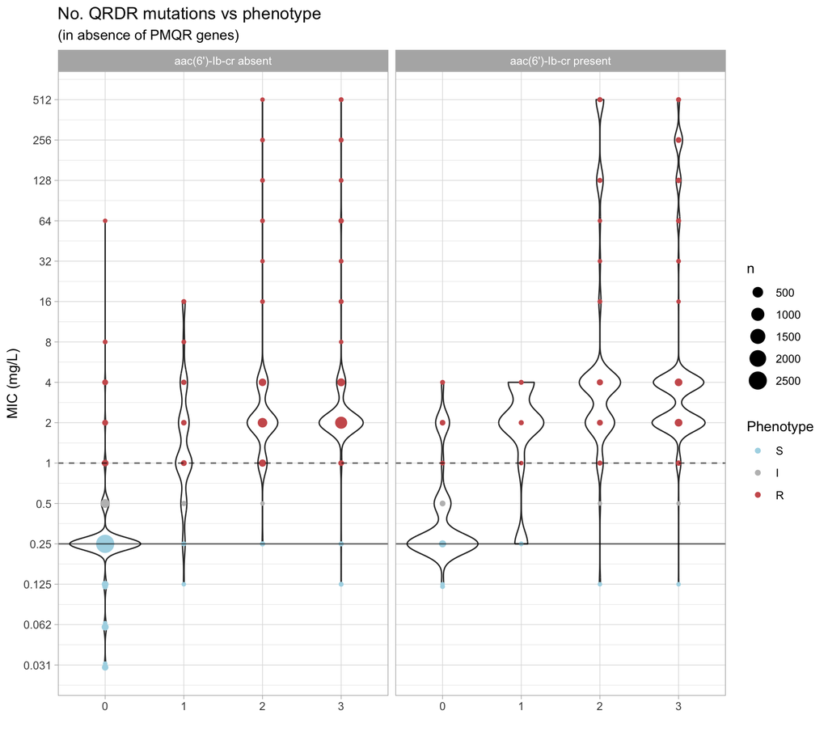

```r
cipro_antibiogram$Resistance.phenotype <- factor(cipro_antibiogram$Resistance.phenotype, levels=c('S', 'I', 'R'))

#MIC distribution for # QRDR, in absence of genes
QRDR_MIC_noGenes <- cipro_antibiogram %>%
    filter(acquired_genes==0) %>%
    filter(grepl('MIC.*$', Laboratory.Typing.Method)) %>%
    mutate(aac6_label=if_else(aac6==0, "aac(6')-Ib-cr absent", "aac(6')-Ib-cr present")) %>%
    mutate(QRDR_mutations=if_else(QRDR_mutations==4, 3, QRDR_mutations)) %>% # single isolate with 4 QRDR
    ggplot(aes(x=factor(QRDR_mutations), y=as.numeric(Measurement))) +
    geom_violin() +
    geom_count(aes(colour = Resistance.phenotype)) +
    geom_hline(aes(yintercept = 1), linetype = 2, alpha = 0.6, color = "black")  +
    geom_hline(aes(yintercept = 0.25), linetype = 1, alpha = 0.6, color = "black")  +
    facet_wrap(vars(aac6_label)) +
    scale_y_continuous(trans = log2_trans(), breaks = 2^(-5:9), labels = function(x) round(as.numeric(x), digits = 3)) +
    scale_color_manual(values = c("I"="grey", "R"="IndianRed", "S"="LightBlue")) +
    theme_light() +
    labs(y="MIC (mg/L)", x="", col="Phenotype",
         title="No. QRDR mutations vs phenotype",
         subtitle="(in absence of PMQR genes)")

QRDR_MIC_noGenes
```

```r
QRDR_pheno_noGenes <- cipro_antibiogram %>%
    filter(acquired_genes==0) %>%
    filter(grepl('MIC.*$', Laboratory.Typing.Method)) %>%
    mutate(aac6_label=if_else(aac6==0, "aac(6')-Ib-cr absent", "aac(6')-Ib-cr present")) %>%
    mutate(QRDR_mutations=if_else(QRDR_mutations==4, 3, QRDR_mutations)) %>% # single isolate with 4 QRDR
    ggplot(aes(x=factor(QRDR_mutations), fill=Resistance.phenotype)) +
    geom_bar(stat='count', position='fill') +
    facet_wrap(vars(aac6_label)) +
    scale_fill_manual(values = res_colours) +
    scale_y_continuous(labels=scales::percent_format()) +
    geom_text(aes(label=..count..), stat="count", position=position_fill(vjust = .5), size=2) +
    theme_light() +
    labs(y="% Phenotype", x="Number of QRDR mutations") +
    theme(legend.position="none", strip.background = element_blank(), strip.text = element_blank())
```

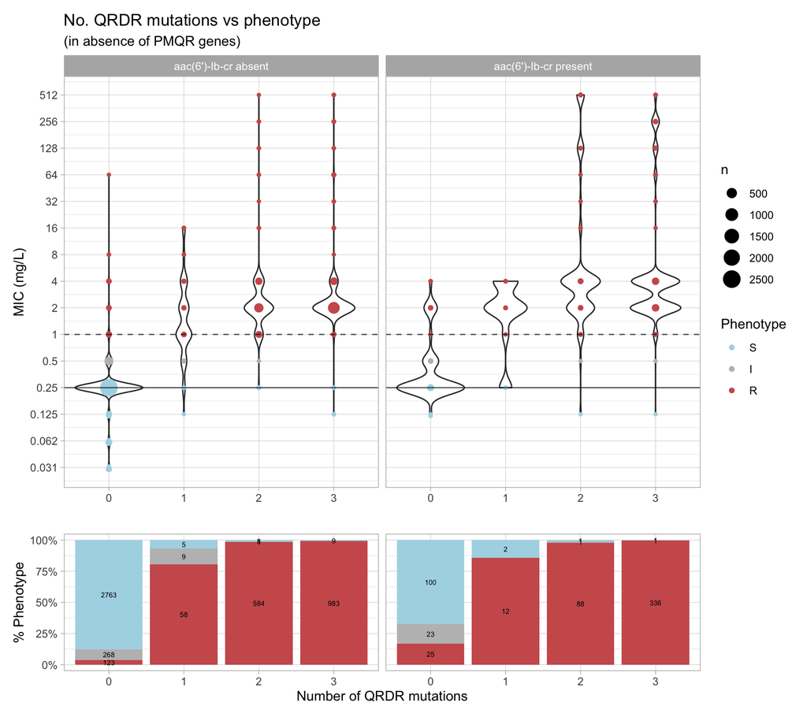

```r
QRDR_MIC_noGenes / QRDR_pheno_noGenes + plot_layout(heights=c(3,1))
```

```r
ggsave("figs/Fig1_numQRDR_MIC_pheno.pdf", width=6, height=5)
ggsave("figs/Fig1_numQRDR_MIC_pheno.png", width=6, height=5)
```

# Supp Fig - number of QRDR vs DD, facet aac6 yes/no (no other genes)

```r
# DD distribution for # QRDR, in absence of genes
QRDR_DD_noGenes <- cipro_antibiogram %>%
    filter(acquired_genes==0) %>%
    filter(Laboratory.Typing.Method=="Disk diffusion") %>%
    mutate(aac6_label=if_else(aac6==0, "aac(6')-Ib-cr absent", "aac(6')-Ib-cr present")) %>%
    mutate(QRDR_mutations=if_else(QRDR_mutations==4, 3, QRDR_mutations)) %>% # single isolate with 4 QRDR
    ggplot(aes(x=factor(QRDR_mutations), y=as.numeric(Measurement))) +
    geom_violin() +
    geom_count(aes(colour = Resistance.phenotype)) +
    geom_hline(aes(yintercept = 21.0), linetype = 1, alpha = 0.6, color = "black") +
    geom_hline(aes(yintercept = 25.0), linetype = 2, alpha = 0.6, color = "black") +
    facet_wrap(vars(aac6_label)) +
    scale_colour_manual(values = res_colours) +
    theme_light() +
    labs(y="Disk zone (mm)", x="", col="Phenotype",
         title="No. QRDR mutations vs phenotype",
         subtitle="(in absence of PMQR genes)")


QRDR_DDpheno_noGenes <- cipro_antibiogram %>%
    filter(acquired_genes==0) %>%
    filter(Laboratory.Typing.Method=="Disk diffusion") %>%
    mutate(aac6_label=if_else(aac6==0, "aac(6')-Ib-cr absent", "aac(6')-Ib-cr present")) %>%
    mutate(QRDR_mutations=if_else(QRDR_mutations==4, 3, QRDR_mutations)) %>% # single isolate with 4 QRDR
    ggplot(aes(x=factor(QRDR_mutations), fill=Resistance.phenotype)) +
    geom_bar(stat='count', position='fill') +
    facet_wrap(vars(aac6_label)) +
     scale_fill_manual(values = res_colours) +
    scale_y_continuous(labels=scales::percent_format()) +
    geom_text(aes(label=..count..), stat="count", position=position_fill(vjust = .5), size=2) +
    theme_light() +
    labs(y="% Phenotype", x="Number of QRDR mutations") +
    theme(legend.position="none", strip.background = element_blank(), strip.text = element_blank())
```

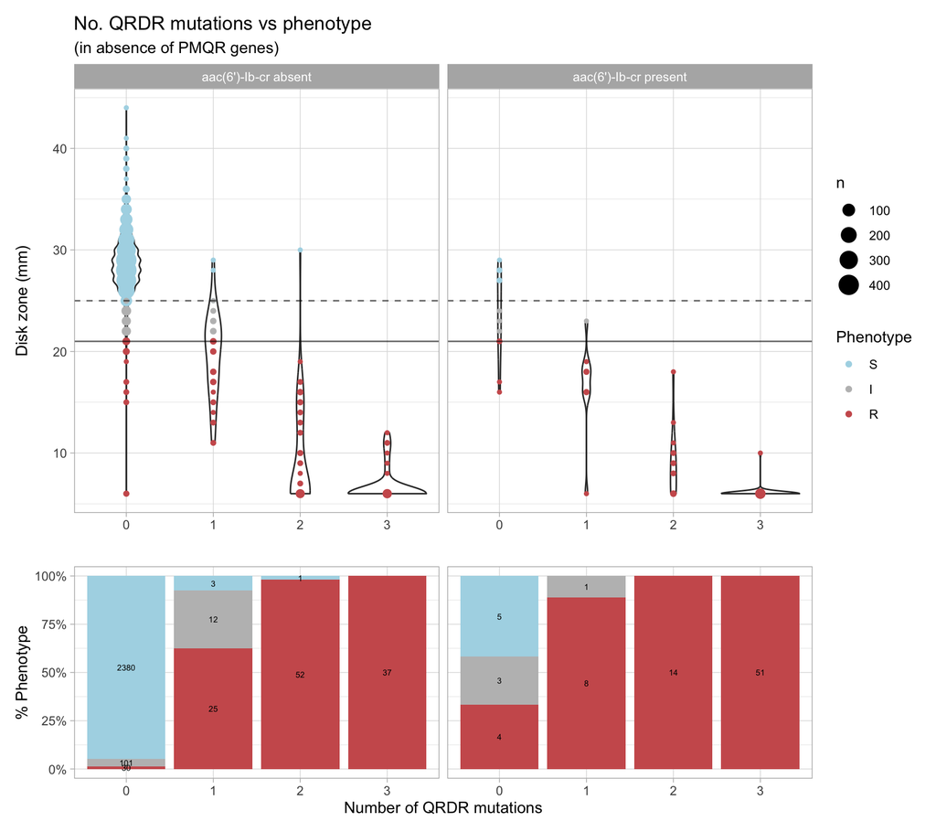

```r
QRDR_DD_noGenes / QRDR_DDpheno_noGenes + plot_layout(heights=c(2,1))
```

```r
ggsave("figs/FigS5_numQRDR_DD_pheno.pdf", width=6, height=4)
ggsave("figs/FigS5_numQRDR_DD_pheno.png", width=6, height=4)
```

# Supp Fig panel - upset plot of QRDR positions, absence of aac6/acquired genes, with MIC data

```r
upset_QRDR_noAac6_MIC <- cipro_antibiogram %>%
  filter(aac6==0 & acquired_genes==0) %>%
  filter(grepl('MIC.*$', Laboratory.Typing.Method)) %>%
  upset(
      intersect=c("GyrA83","GyrA87", "ParC80","ParC84","wt_QRDR"), # counts are converted to binary
      set_sizes=(upset_set_size() +
                    theme(axis.text.x=element_text(angle=45),axis.ticks.x=element_line())),
      base_annotations=list( # add stacked barplot showing WT/nonWT
        'Percent of genomes'=list(
        aes=aes(x=intersection, fill=Resistance.phenotype),
          geom=list(
            geom_bar(stat='count', position='fill'),
            theme(legend.position = "none", axis.title=element_text(size=8)),
                 scale_fill_manual(values = res_colours),
            scale_y_continuous(labels=scales::percent_format()),
            geom_text(aes(label=..count..), stat="count", position=position_fill(vjust = .5), angle = 45, size=2))
        )
      ),
      annotations= list( # add violin plot with MIC data
        'MIC measurement (mg/L)'=(
            ggplot(mapping=aes(y=as.numeric(Measurement))) +
              geom_hline(aes(yintercept = 1), linetype = 2, alpha = 0.6, color = "black")  +
              geom_hline(aes(yintercept = 0.25), linetype = 1, alpha = 0.6, color = "black")  +
              geom_violin()+
              geom_count(aes(colour = Resistance.phenotype))+
               scale_colour_manual(values = res_colours) +
              scale_y_continuous(trans = log2_trans(), breaks = 2^(-5:9), labels = function(x) round(as.numeric(x), digits = 3), limits=c(2^-5,2^9)) +
              theme(legend.position = "none", axis.title=element_text(size=8))  +
              ggtitle("aac(6')-Ib-cr absent")
        )
      )
    ) + patchwork::plot_layout(heights=c(3,1,1)) # relative heights of plotting areas
```

# Supp Fig panel- upset plot of QRDR positions, presence of aac6 but no other acquired genes, with MIC data

```r
upset_QRDR_aac6_MIC <- cipro_antibiogram %>%
  filter(aac6==1 & acquired_genes==0) %>%
  filter(grepl('MIC.*$', Laboratory.Typing.Method)) %>%
  upset(
      intersect=c("GyrA83","GyrA87", "ParC80","ParC84","wt_QRDR"), # counts are converted to binary
      set_sizes=(upset_set_size() +
                    theme(axis.text.x=element_text(angle=45),axis.ticks.x=element_line())),
      base_annotations=list( # add stacked barplot showing WT/nonWT
        'Percent of genomes'=list(
        aes=aes(x=intersection, fill=Resistance.phenotype),
          geom=list(
            geom_bar(stat='count', position='fill'),
            theme(legend.position = "none", axis.title=element_text(size=8)),
              scale_fill_manual(values = c("I"="grey", "R"="IndianRed", "S"="LightBlue")),
            scale_y_continuous(labels=scales::percent_format()),
            geom_text(aes(label=..count..), stat="count", position=position_fill(vjust = .5), angle = 45, size=2))
        )
      ),
      annotations= list( # add violin plot with MIC data
        'MIC measurement (mg/L)'=(
            ggplot(mapping=aes(y=as.numeric(Measurement))) +
              geom_hline(aes(yintercept = 1), linetype = 2, alpha = 0.6, color = "black")  +
              geom_hline(aes(yintercept = 0.25), linetype = 1, alpha = 0.6, color = "black")  +
              geom_violin()+
              geom_count(aes(colour = Resistance.phenotype))+
               scale_colour_manual(values = res_colours) +
              scale_y_continuous(trans = log2_trans(), breaks = 2^(-5:9), labels = function(x) round(as.numeric(x), digits = 3), limits=c(2^-5,2^9)) +
              labs(colour = "Phenotype") +
              theme(axis.title=element_text(size=8)) +
              ggtitle("aac(6')-Ib-cr present")
        )
      )
    ) + patchwork::plot_layout(heights=c(3,1,1)) # relative heights of plotting areas
```

# Supp Fig panel - QRDR positions, absence of aac6/acquired genes, with DD data

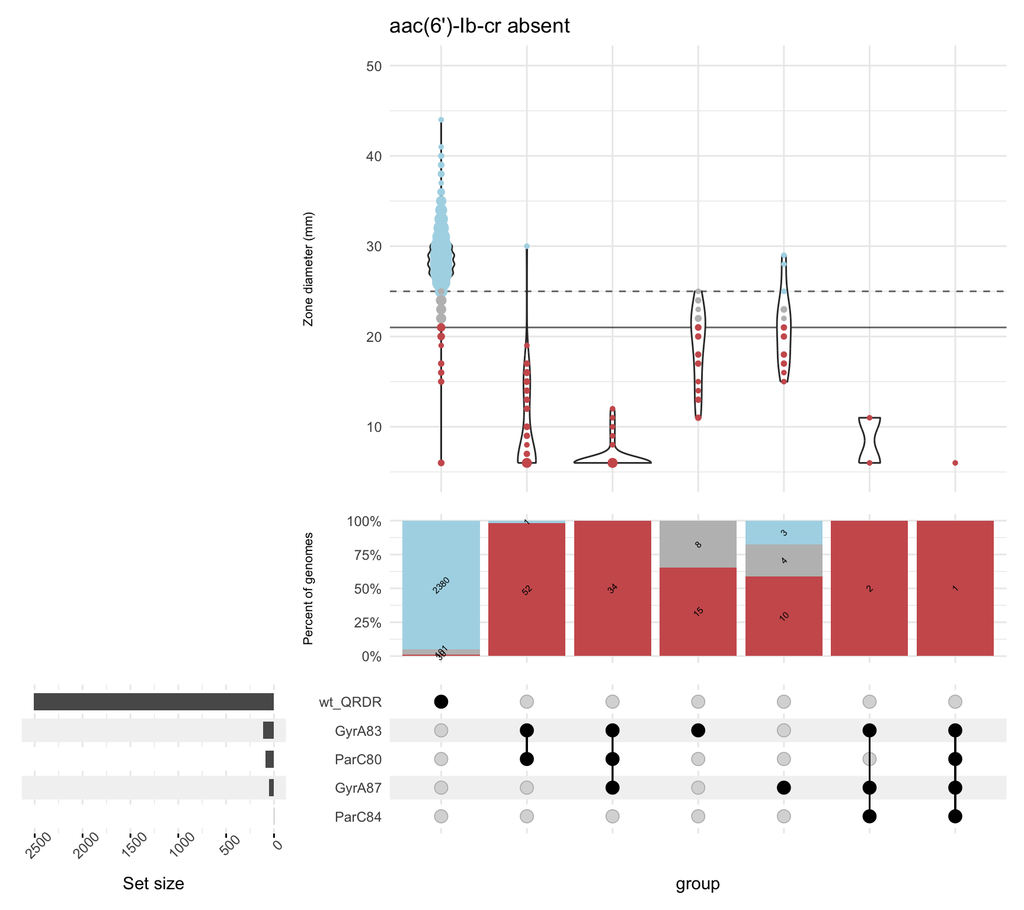

```r
upset_QRDR_noAac6_DD <- cipro_antibiogram %>%
  filter(aac6==0 & acquired_genes==0) %>%
  filter(Laboratory.Typing.Method == "Disk diffusion") %>%
  upset(
      intersect=c("GyrA83","GyrA87", "ParC80","ParC84","wt_QRDR"), # counts are converted to binary
      set_sizes=(upset_set_size() +
                    theme(axis.text.x=element_text(angle=45), axis.ticks.x=element_line())),
      base_annotations=list( # add stacked barplot showing S/nonS
        'Percent of genomes'=list(
        aes=aes(x=intersection, fill=Resistance.phenotype),
          geom=list(
            geom_bar(stat='count', position='fill'),
             scale_fill_manual(values = c("I"="grey", "R"="IndianRed", "S"="LightBlue")),
            scale_y_continuous(labels=scales::percent_format()),
            theme(legend.position = "none", axis.title=element_text(size=8)),
            geom_text(aes(label=..count..), stat="count", position=position_fill(vjust = .5), angle = 45, size=2))
        )
      ),
      annotations= list( # add violin plot with disk diffusion data
        'Zone diameter (mm)'=(
            ggplot(mapping=aes(y=as.numeric(Measurement))) +
              geom_hline(aes(yintercept = 21.0), linetype = 1, alpha = 0.6, color = "black") +
              geom_hline(aes(yintercept = 25.0), linetype = 2, alpha = 0.6, color = "black") +
              geom_violin()+
              geom_count(aes(colour = Resistance.phenotype))+
               scale_colour_manual(values = res_colours) +
              guides(size = "none") +
              labs(linetype = "CLSI/EUCAST", colour = "Phenotype") +
              ggtitle("Disk diffusion data") +
              theme(axis.title=element_text(size=8), legend.position="none") +
              ggtitle("aac(6')-Ib-cr absent") + ylim(5,50)
        )
      )
    ) + patchwork::plot_layout(heights=c(3,1,1)) # relative heights of plotting areas

upset_QRDR_noAac6_DD
```

# Supp Fig panel - QRDR positions, presence of aac6 but no other acquired genes, with DD data

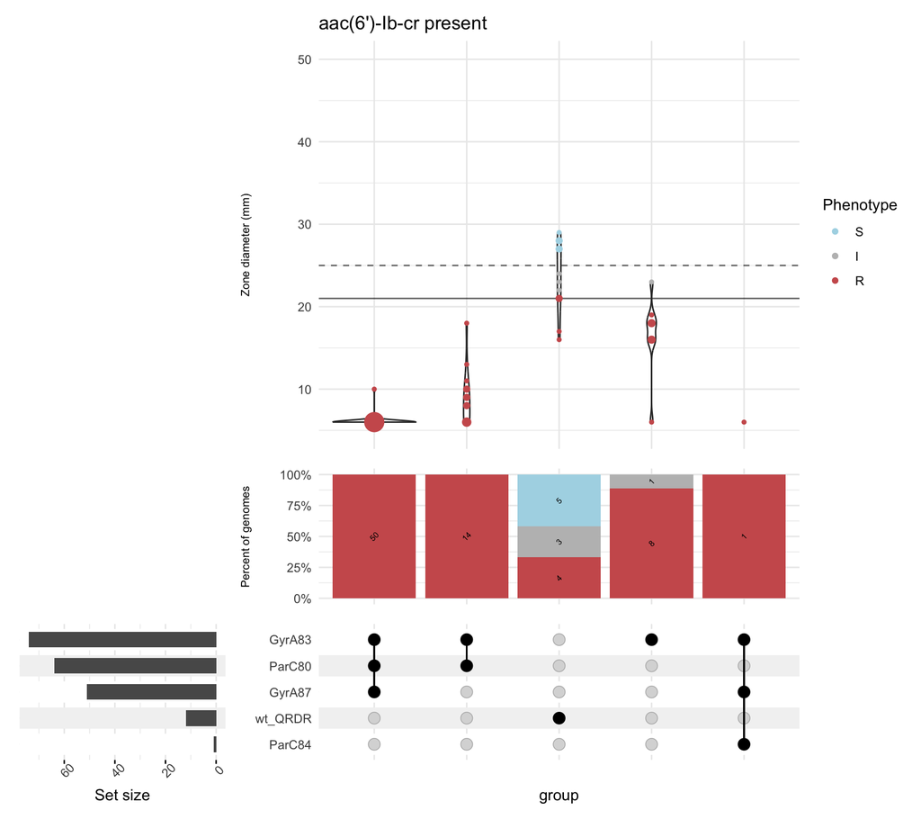

```r
upset_QRDR_aac6_DD <- cipro_antibiogram %>%
  filter(aac6==1 & acquired_genes==0) %>%
  filter(Laboratory.Typing.Method == "Disk diffusion") %>%
  upset(
      intersect=c("GyrA83","GyrA87", "ParC80","ParC84","wt_QRDR"), # counts are converted to binary
      set_sizes=(upset_set_size() +
                    theme(axis.text.x=element_text(angle=45), axis.ticks.x=element_line())),
      base_annotations=list( # add stacked barplot showing S/nonS
        'Percent of genomes'=list(
        aes=aes(x=intersection, fill=Resistance.phenotype),
          geom=list(
            geom_bar(stat='count', position='fill'),
               scale_fill_manual(values = c("I"="grey", "R"="IndianRed", "S"="LightBlue")),
            scale_y_continuous(labels=scales::percent_format()),
            theme(legend.position = "none", axis.title=element_text(size=8)),
            geom_text(aes(label=..count..), stat="count", position=position_fill(vjust = .5), angle = 45, size=2))
        )
      ),
      annotations= list( # add violin plot with disk diffusion data
        'Zone diameter (mm)'=(
            ggplot(mapping=aes(y=as.numeric(Measurement))) +
              geom_hline(aes(yintercept = 21.0), linetype = 1, alpha = 0.6, color = "black") +
              geom_hline(aes(yintercept = 25.0), linetype = 2, alpha = 0.6, color = "black") +
              geom_violin()+
              geom_count(aes(colour = Resistance.phenotype))+
               scale_color_manual(values = c("I"="grey", "R"="IndianRed", "S"="LightBlue")) +
              guides(size = "none") +
              labs(linetype = "CLSI/EUCAST", colour = "Phenotype") +
              ggtitle("aac(6')-Ib-cr present") +
              theme(axis.title=element_text(size=8)) + ylim(5,50)
        )
      )
    ) + patchwork::plot_layout(heights=c(3,1,1)) # relative heights of plotting areas

upset_QRDR_aac6_DD
```

## Supp Figs: QRDR sites vs pheno (MIC & DD, with/without aac6)

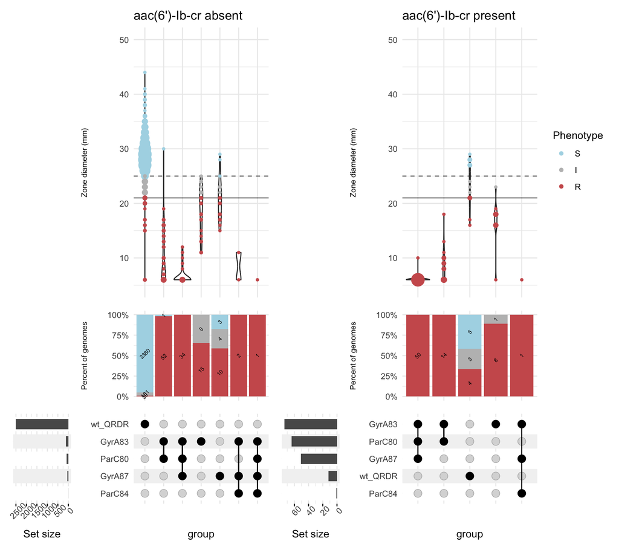

```r
upset_QRDR_noAac6_DD | upset_QRDR_aac6_DD
```

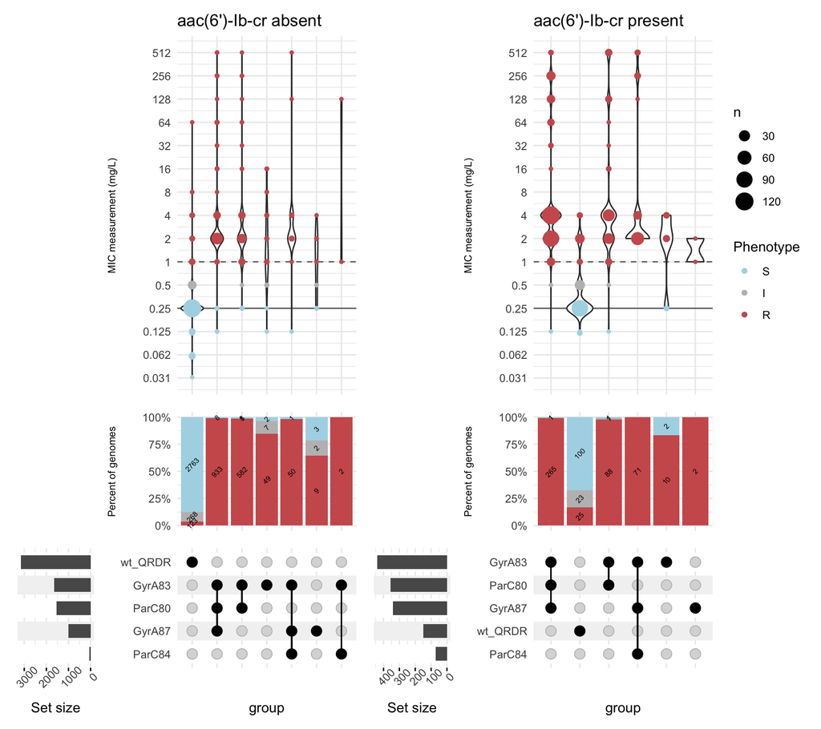

```r
ggsave("figs/FigS4_QRDR_DD.pdf", width=9, height=6)
ggsave("figs/FigS4_QRDR_DD.png", width=9, height=6)


upset_QRDR_noAac6_MIC | upset_QRDR_aac6_MIC
```

```r
ggsave("figs/FigS3_QRDR_MIC.pdf", width=9, height=6)
ggsave("figs/FigS3_QRDR_MIC.png", width=9, height=6)
```

# effect of qnr/qep genes, in absence of QRDR and aac6

```r
# MIC
qnr_MIC_nullBG_dat <- mic %>%
    filter(aac6==0 & QRDR_mutations==0) %>%
  select(Measurement, Resistance.phenotype, resistant, nonWT_binary, acquired_genes) %>%
  mutate(acquired_bin=if_else(acquired_genes==0, 0, 1))

# MIC vs presence/absence of qnr
wilcox.test(log2(as.numeric(Measurement)) ~ acquired_bin, data=qnr_MIC_nullBG_dat)
```

```
##
##  Wilcoxon rank sum test with continuity correction
##
## data:  log2(as.numeric(Measurement)) by acquired_bin
## W = 144012, p-value < 2.2e-16
## alternative hypothesis: true location shift is not equal to 0
```

```r
t.test(log2(as.numeric(Measurement)) ~ acquired_bin, data=qnr_MIC_nullBG_dat)
```

```
##
##  Welch Two Sample t-test
##
## data:  log2(as.numeric(Measurement)) by acquired_bin
## t = -43.05, df = 767.85, p-value < 2.2e-16
## alternative hypothesis: true difference in means between group 0 and group 1 is not equal to 0
## 95 percent confidence interval:
##  -2.229128 -2.034700
## sample estimates:
## mean in group 0 mean in group 1
##      -1.9442169       0.1876972
```

```r
summary(lm(log2(as.numeric(Measurement)) ~ acquired_bin, data=qnr_MIC_nullBG_dat))
```

```
##
## Call:
## lm(formula = log2(as.numeric(Measurement)) ~ acquired_bin, data = qnr_MIC_nullBG_dat)
##
## Residuals:
##     Min      1Q  Median      3Q     Max
## -3.1877 -0.0558 -0.0558 -0.0558  7.9442
##
## Coefficients:
##              Estimate Std. Error t value Pr(>|t|)
## (Intercept)  -1.94422    0.01627 -119.50   <2e-16 ***
## acquired_bin  2.13191    0.03977   53.61   <2e-16 ***
## ---
## Signif. codes:  0 '***' 0.001 '**' 0.01 '*' 0.05 '.' 0.1 ' ' 1
##
## Residual standard error: 0.9137 on 3786 degrees of freedom
## Multiple R-squared:  0.4315, Adjusted R-squared:  0.4314
## F-statistic:  2874 on 1 and 3786 DF,  p-value: < 2.2e-16
```

```r
summary(as.numeric(qnr_MIC_nullBG_dat$Measurement)[qnr_MIC_nullBG_dat$acquired_bin==1])
```

```
##    Min. 1st Qu.  Median    Mean 3rd Qu.    Max.
##   0.125   0.500   1.000   1.577   2.000   8.000
```

```r
summary(as.numeric(qnr_MIC_nullBG_dat$Measurement)[qnr_MIC_nullBG_dat$acquired_bin==0])
```

```
##    Min. 1st Qu.  Median    Mean 3rd Qu.    Max.
##  0.0300  0.2500  0.2500  0.3464  0.2500 64.0000
```

```r
# MIC vs qnr count
summary(lm(log2(as.numeric(Measurement)) ~ acquired_genes, data=qnr_MIC_nullBG_dat))
```

```
##
## Call:
## lm(formula = log2(as.numeric(Measurement)) ~ acquired_genes,
##     data = qnr_MIC_nullBG_dat)
##
## Residuals:
##     Min      1Q  Median      3Q     Max
## -3.1214 -0.0626 -0.0626 -0.0626  7.9374
##
## Coefficients:
##                Estimate Std. Error t value Pr(>|t|)
## (Intercept)    -1.93745    0.01625  -119.2   <2e-16 ***
## acquired_genes  2.02751    0.03797    53.4   <2e-16 ***
## ---
## Signif. codes:  0 '***' 0.001 '**' 0.01 '*' 0.05 '.' 0.1 ' ' 1
##
## Residual standard error: 0.9152 on 3786 degrees of freedom
## Multiple R-squared:  0.4296, Adjusted R-squared:  0.4295
## F-statistic:  2852 on 1 and 3786 DF,  p-value: < 2.2e-16
```

```r
summary(as.numeric(qnr_MIC_nullBG_dat$Measurement)[qnr_MIC_nullBG_dat$acquired_genes==1])
```

```
##    Min. 1st Qu.  Median    Mean 3rd Qu.    Max.
##   0.125   0.500   1.000   1.548   2.000   8.000
```

```r
summary(as.numeric(qnr_MIC_nullBG_dat$Measurement)[qnr_MIC_nullBG_dat$acquired_genes==2])
```

```
##    Min. 1st Qu.  Median    Mean 3rd Qu.    Max.
##   0.500   1.000   2.000   2.475   4.000   4.000
```

```r
summary(as.numeric(qnr_MIC_nullBG_dat$Measurement)[qnr_MIC_nullBG_dat$acquired_genes>2])
```

```
##    Min. 1st Qu.  Median    Mean 3rd Qu.    Max.
##
```

```r
# DD
qnr_DD_noGenes_dat <- cipro_antibiogram %>%
    filter(aac6==0 & QRDR_mutations==0) %>%
    filter(Laboratory.Typing.Method=="Disk diffusion") %>%
  select(Measurement, Resistance.phenotype, resistant, nonWT_binary, acquired_genes) %>%
  mutate(acquired_bin=if_else(acquired_genes==0, 0, 1))

# DD vs presence/absence
wilcox.test(as.numeric(Measurement) ~ acquired_bin, data=qnr_DD_noGenes_dat)
```

```
##
##  Wilcoxon rank sum test with continuity correction
##
## data:  as.numeric(Measurement) by acquired_bin
## W = 230345, p-value < 2.2e-16
## alternative hypothesis: true location shift is not equal to 0
```

```r
t.test(as.numeric(Measurement) ~ acquired_bin, data=qnr_DD_noGenes_dat)
```

```
##
##  Welch Two Sample t-test
##
## data:  as.numeric(Measurement) by acquired_bin
## t = 17.206, df = 97.257, p-value < 2.2e-16
## alternative hypothesis: true difference in means between group 0 and group 1 is not equal to 0
## 95 percent confidence interval:
##   8.09942 10.21149
## sample estimates:
## mean in group 0 mean in group 1
##        28.66587        19.51042
```

```r
summary(lm(as.numeric(Measurement) ~ acquired_bin, data=qnr_DD_noGenes_dat))
```

```
##
## Call:
## lm(formula = as.numeric(Measurement) ~ acquired_bin, data = qnr_DD_noGenes_dat)
##
## Residuals:
##      Min       1Q   Median       3Q      Max
## -22.6659  -1.6659   0.3341   1.3341  15.3341
##
## Coefficients:
##              Estimate Std. Error t value Pr(>|t|)
## (Intercept)  28.66587    0.05979  479.41   <2e-16 ***
## acquired_bin -9.15545    0.31160  -29.38   <2e-16 ***
## ---
## Signif. codes:  0 '***' 0.001 '**' 0.01 '*' 0.05 '.' 0.1 ' ' 1
##
## Residual standard error: 2.996 on 2605 degrees of freedom
## Multiple R-squared:  0.2489, Adjusted R-squared:  0.2486
## F-statistic: 863.3 on 1 and 2605 DF,  p-value: < 2.2e-16
```

```r
summary(as.numeric(qnr_DD_noGenes_dat$Measurement)[qnr_DD_noGenes_dat$acquired_bin==1])
```

```
##    Min. 1st Qu.  Median    Mean 3rd Qu.    Max.
##    6.00   17.00   21.00   19.51   22.00   31.00
```

```r
summary(as.numeric(qnr_DD_noGenes_dat$Measurement)[qnr_DD_noGenes_dat$acquired_bin==0])
```

```
##    Min. 1st Qu.  Median    Mean 3rd Qu.    Max.
##    6.00   27.00   29.00   28.67   30.00   44.00
```

```r
# DD vs qnr count
summary(lm(as.numeric(Measurement) ~ acquired_genes, data=qnr_DD_noGenes_dat))
```

```
##
## Call:
## lm(formula = as.numeric(Measurement) ~ acquired_genes, data = qnr_DD_noGenes_dat)
##
## Residuals:
##      Min       1Q   Median       3Q      Max
## -22.6642  -1.6642   0.3358   1.3358  15.3358
##
## Coefficients:
##                Estimate Std. Error t value Pr(>|t|)
## (Intercept)    28.66417    0.05939  482.65   <2e-16 ***
## acquired_genes -8.65839    0.28782  -30.08   <2e-16 ***
## ---
## Signif. codes:  0 '***' 0.001 '**' 0.01 '*' 0.05 '.' 0.1 ' ' 1
##
## Residual standard error: 2.978 on 2605 degrees of freedom
## Multiple R-squared:  0.2578, Adjusted R-squared:  0.2575
## F-statistic:   905 on 1 and 2605 DF,  p-value: < 2.2e-16
```

```r
summary(as.numeric(qnr_DD_noGenes_dat$Measurement)[qnr_DD_noGenes_dat$acquired_genes==1])
```

```
##    Min. 1st Qu.  Median    Mean 3rd Qu.    Max.
##    6.00   18.00   21.00   19.91   22.50   31.00
```

```r
summary(as.numeric(qnr_DD_noGenes_dat$Measurement)[qnr_DD_noGenes_dat$acquired_genes==2])
```

```
##    Min. 1st Qu.  Median    Mean 3rd Qu.    Max.
##     6.0     6.0    10.0    12.2    17.0    22.0
```

```r
summary(as.numeric(qnr_DD_noGenes_dat$Measurement)[qnr_DD_noGenes_dat$acquired_genes>2])
```

```
##    Min. 1st Qu.  Median    Mean 3rd Qu.    Max.
##
```

```r
# all genomes with no acquired genes (MIC/DD)
qnr_noGenes_dat <- cipro_antibiogram %>%
    filter(aac6==0 & QRDR_mutations==0) %>%
  select(Measurement, Resistance.phenotype, resistant, nonWT_binary, acquired_genes) %>%
  mutate(acquired_bin=if_else(acquired_genes==0, 0, 1))

dim(qnr_noGenes_dat)
```

```
## [1] 6395    6
```

```r
# nonS vs presence/absence
fisher.test(table(qnr_noGenes_dat$nonWT_binary, qnr_noGenes_dat$acquired_bin))
```

```
##
##  Fisher's Exact Test for Count Data
##
## data:  table(qnr_noGenes_dat$nonWT_binary, qnr_noGenes_dat$acquired_bin)
## p-value < 2.2e-16
## alternative hypothesis: true odds ratio is not equal to 1
## 95 percent confidence interval:
##   84.12867 150.39683
## sample estimates:
## odds ratio
##   112.2407
```

```r
# resistance vs presence/absence
fisher.test(table(qnr_noGenes_dat$resistant, qnr_noGenes_dat$acquired_bin))
```

```
##
##  Fisher's Exact Test for Count Data
##
## data:  table(qnr_noGenes_dat$resistant, qnr_noGenes_dat$acquired_bin)
## p-value < 2.2e-16
## alternative hypothesis: true odds ratio is not equal to 1
## 95 percent confidence interval:
##   68.34106 108.80715
## sample estimates:
## odds ratio
##   86.07533
```

# Figure 2 - number of qnr/qep vs MIC, facet aac6 yes/no (no QRDR)

```r
# MIC distribution for # QRDR, in absence of genes
qnr_MIC_noGenes <- cipro_antibiogram %>%
    filter(QRDR_mutations==0) %>%
    filter(grepl('MIC.*$', Laboratory.Typing.Method)) %>%
    mutate(aac6_label=if_else(aac6==0, "aac(6')-Ib-cr absent", "aac(6')-Ib-cr present")) %>%
    ggplot(aes(x=factor(acquired_genes), y=as.numeric(Measurement))) +
    geom_violin() +
    geom_count(aes(colour = Resistance.phenotype)) +
    geom_hline(aes(yintercept = 1), linetype = 2, alpha = 0.6, color = "black")  +
    geom_hline(aes(yintercept = 0.25), linetype = 1, alpha = 0.6, color = "black")  +
    facet_wrap(vars(aac6_label)) +
    scale_y_continuous(trans = log2_trans(), breaks = 2^(-5:9), labels = function(x) round(as.numeric(x), digits = 3)) +
    scale_color_manual(values = res_colours) +
    theme_light() +
    labs(y="MIC (mg/L)", x="", col="Phenotype",
         title="No. PMQR genes vs phenotype",
         subtitle="(in absence of QRDR mutations)")


qnr_pheno_noGenes <- cipro_antibiogram %>%
    filter(QRDR_mutations==0) %>%
    filter(grepl('MIC.*$', Laboratory.Typing.Method)) %>%
    mutate(aac6_label=if_else(aac6==0, "aac(6')-Ib-cr absent", "aac(6')-Ib-cr present")) %>%
    ggplot(aes(x=factor(acquired_genes), fill=Resistance.phenotype)) +
    geom_bar(stat='count', position='fill') +
    facet_wrap(vars(aac6_label)) +
       scale_fill_manual(values = res_colours) +
    scale_y_continuous(labels=scales::percent_format()) +
    geom_text(aes(label=..count..), stat="count", position=position_fill(vjust = .5), size=2) +
    theme_light() +
    labs(y="% Phenotype", x="Number of PMQR genes") +
    theme(legend.position="none", strip.background = element_blank(), strip.text = element_blank())
```

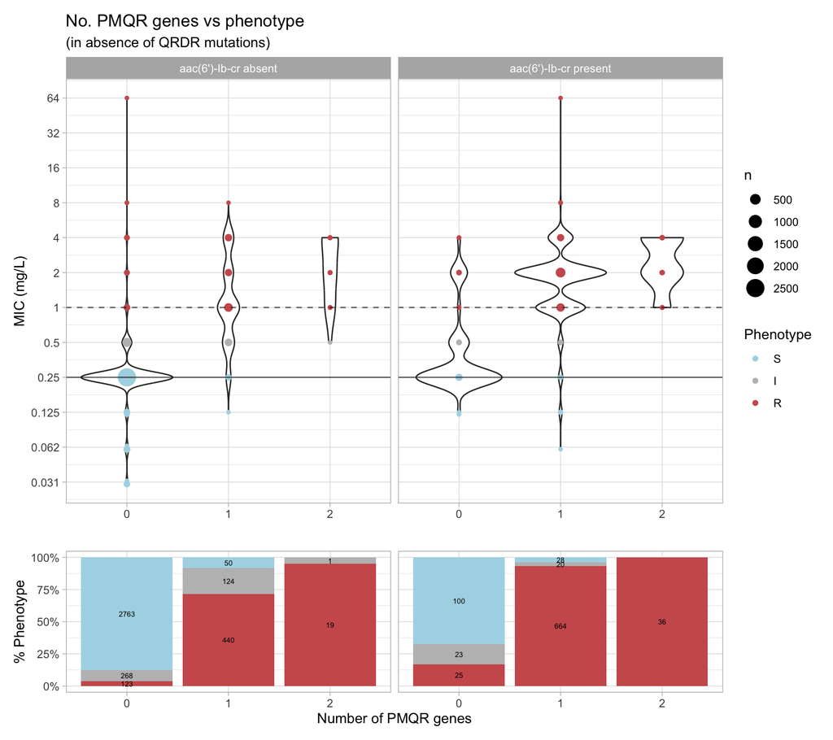

```r
qnr_MIC_noGenes / qnr_pheno_noGenes + plot_layout(heights=c(3,1))
```

```r
ggsave("Fig2_numQnr_MIC_pheno.pdf", width=6, height=5)
ggsave("Fig2_numQnr_MIC_pheno.png", width=6, height=5)
```

# (Fig S8) - number of qnr vs DD, facet aac6 yes/no (no QRDR)

```r
# DD distribution for # qnr, in absence of genes
qnr_DD_noGenes <- cipro_antibiogram %>%
    filter(QRDR_mutations==0) %>%
    filter(Laboratory.Typing.Method=="Disk diffusion") %>%
    mutate(aac6_label=if_else(aac6==0, "aac(6')-Ib-cr absent", "aac(6')-Ib-cr present")) %>%
    ggplot(aes(x=factor(acquired_genes), y=as.numeric(Measurement))) +
    geom_violin() +
    geom_count(aes(colour = Resistance.phenotype)) +
    geom_hline(aes(yintercept = 21.0), linetype = 1, alpha = 0.6, color = "black") +
    geom_hline(aes(yintercept = 25.0), linetype = 2, alpha = 0.6, color = "black") +
    facet_wrap(vars(aac6_label)) +
      scale_color_manual(values = res_colours) +
    theme_light() +
    labs(y="Disk zone (mm)", x="", col="Phenotype",
         title="No. PMQR genes vs phenotype",
         subtitle="(in absence of QRDR mutations)")


qnr_DDpheno_noGenes <- cipro_antibiogram %>%
    filter(QRDR_mutations==0) %>%
    filter(Laboratory.Typing.Method=="Disk diffusion") %>%
    mutate(aac6_label=if_else(aac6==0, "aac(6')-Ib-cr absent", "aac(6')-Ib-cr present")) %>%
    ggplot(aes(x=factor(acquired_genes), fill=Resistance.phenotype)) +
    geom_bar(stat='count', position='fill') +
    facet_wrap(vars(aac6_label)) +
      scale_fill_manual(values = res_colours) +
    scale_y_continuous(labels=scales::percent_format()) +
    geom_text(aes(label=..count..), stat="count", position=position_fill(vjust = .5), size=2) +
    theme_light() +
    labs(y="% Phenotype", x="Number of PMQR genes") +
    theme(legend.position="none", strip.background = element_blank(), strip.text = element_blank())
```

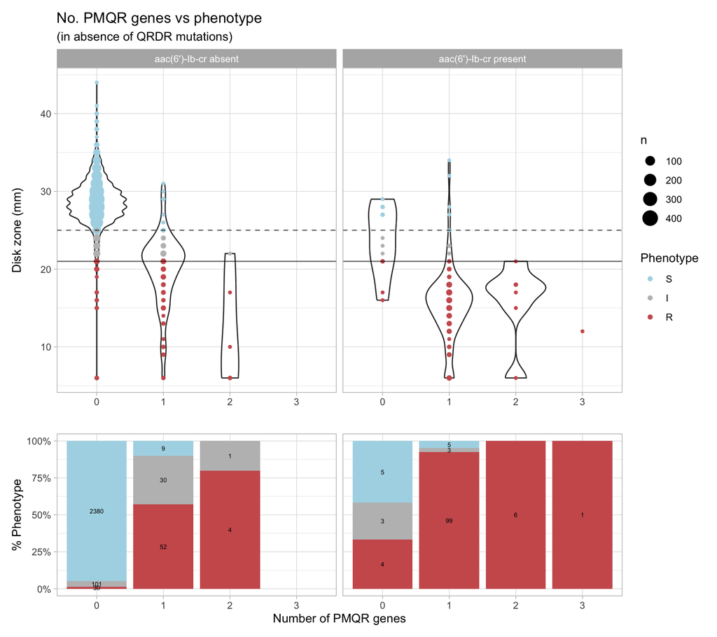

```r
qnr_DD_noGenes / qnr_DDpheno_noGenes + plot_layout(heights=c(2,1))
```

```r
ggsave("FigS8_numQnr_DD_pheno.pdf", width=6, height=4)
ggsave("FigS8_numQnr_DD_pheno.png", width=6, height=4)
```